# Nonparametric HW 6

Ryan Schubert

April 12, 2020

## Question 1

Describe the data. Who is in this data set? What are some of the intersting characteristics of this data set?

```r
colnames(school_data)
```

```
##  [1] "Country"                          "Region"
##  [3] "DataYear"                         "ClassGrade"
##  [5] "Gender"                           "Ageyears"
##  [7] "Handed"                           "Height_cm"
##  [9] "Footlength_cm"                    "Armspan_cm"
## [11] "Languages_spoken"                 "Travel_to_School"
## [13] "Travel_time_to_School"            "Reaction_time"
## [15] "Score_in_memory_game"             "Favourite_physical_activity"
## [17] "Importance_reducing_pollution"    "Importance_recycling_rubbish"
## [19] "Importance_conserving_water"      "Importance_saving_energy"
## [21] "Importance_owning_computer"       "Importance_Internet_access"
## [23] "Left_Footlength_cm"               "Longer_foot"
## [25] "Index_Fingerlength_mm"            "Ring_Fingerlength_mm"
## [27] "Longer_Finger_Lefthand"           "Birth_month"
## [29] "Favorite_Season"                  "Allergies"
## [31] "Vegetarian"                       "Favorite_Food"
## [33] "Beverage"                         "Favorite_School_Subject"
## [35] "Sleep_Hours_Schoolnight"          "Sleep_Hours_Non_Schoolnight"
## [37] "Home_Occupants"                   "Home_Internet_Access"
## [39] "Communication_With_Friends"       "Text_Messages_Sent_Yesterday"
## [41] "Text_Messages_Received_Yesterday" "Hanging_Out_With_Friends_Hours"
## [43] "Talking_On_Phone_Hours"           "Doing_Homework_Hours"
## [45] "Doing_Things_With_Family_Hours"   "Outdoor_Activities_Hours"
## [47] "Video_Games_Hours"                "Social_Websites_Hours"
## [49] "Texting_Messaging_Hours"          "Computer_Use_Hours"
## [51] "Watching_TV_Hours"                "Paid_Work_Hours"
## [53] "Work_At_Home_Hours"               "Schoolwork_Pressure"
## [55] "Planned_Education_Level"          "Favorite_Music"
## [57] "Superpower"                       "Preferred_Status"
## [59] "Role_Model_Type"                  "Charity_Donation"
```

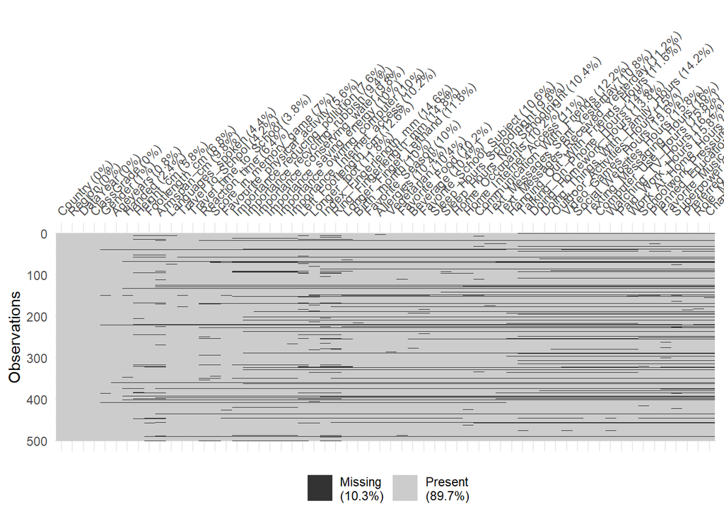

```r
#summary(school_data)
vis_miss(school_data)
```

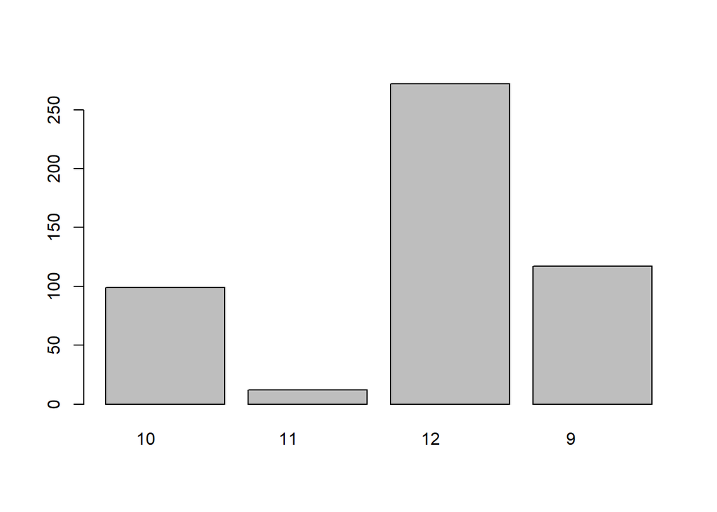

```
##      [,1]
## [1,]  0.7
## [2,]  1.9
## [3,]  3.1
## [4,]  4.3
```

```r
barcount(school_data$ClassGrade) # very few 11th graders, fewer people ~16 which is accurately reflected in the graph
```

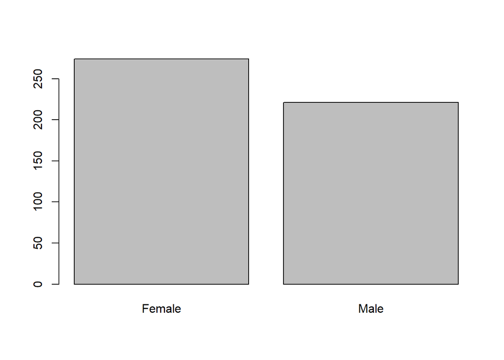

```
##      [,1]
## [1,]  0.7
## [2,]  1.9
```

```r
barcount(school_data$Gender) #gender fairly balanced, with some unknown
```

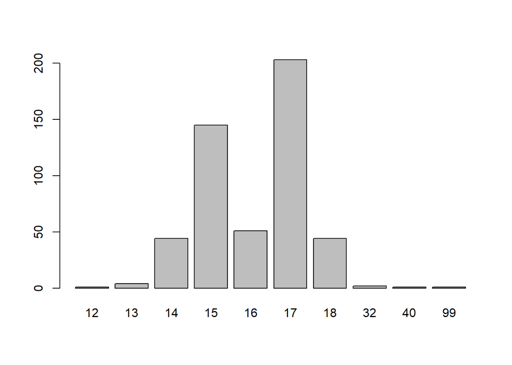

```
##       [,1]
##  [1,]  0.7
##  [2,]  1.9
##  [3,]  3.1
##  [4,]  4.3
##  [5,]  5.5
##  [6,]  6.7
##  [7,]  7.9
##  [8,]  9.1
##  [9,] 10.3
## [10,] 11.5
```

```r
barcount(school_data$Ageyears) #ages should be between roughly 14 to 19 years based on the gardes, though there is some leeway with people skipping grades and people being held back there are clearly incorrect data points
```

```r
#lets check out some weird ones
table(school_data$Preferred_Status)
```

```
##
##  Famous   Happy Healthy    Rich
##      22     238      72      93
```

```r
table(school_data$Superpower)
```

```
##
##            Fly    Freeze time   Invisibility Super strength      Telepathy
##             88            112             81             20            118
```

## Question 2

Perform the appropriate test to test the null hypothesis that handedness (i.e. the variable named Handed) is independent of favorite season vs the alternative hypothesis that there is some dependence. Perform this test after removing responses that are blank. Do you think it is ok here to remove the blanks? Explain why or why not. Explain your reasoning for the test you chose and state your conclusions.

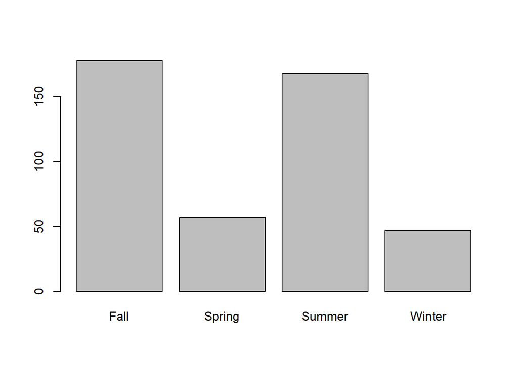

```
##      [,1]
## [1,]  0.7
## [2,]  1.9
## [3,]  3.1
## [4,]  4.3
```

```r
#First lets look at our variables as it should be assumed that data has errors in it

barcount(school_data$Favorite_Season)
```

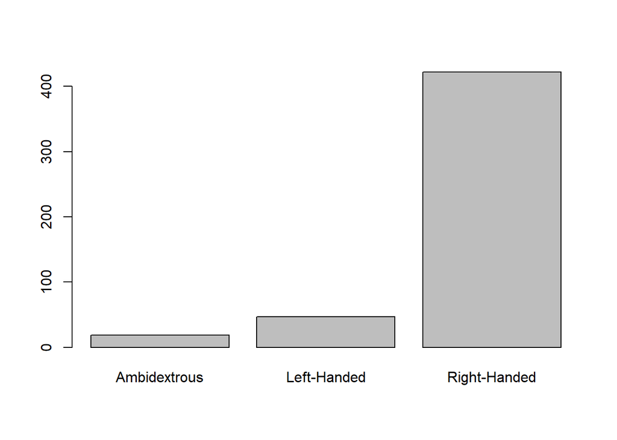

```
##      [,1]
## [1,]  0.7
## [2,]  1.9
## [3,]  3.1
```

```r
barcount(school_data$Handed)
```

```r
table(school_data$Handed)
```

```
##
## Ambidextrous  Left-Handed Right-Handed
##           19           47          422
```

```r
withMissing<-school_data %>% select(Handed,Favorite_Season) %>% table()




# ?chisq.test
##Number of observations depends on when you handle missing data so we will test both as removal methods
school_data %>%
  filter(complete.cases(.)) %>% dim()
```

```
## [1] 324  60
```

```r
school_data %>% select(Handed,Favorite_Season) %>%
  filter(complete.cases(.)) %>% dim()
```

```
## [1] 449   2
```

```r
noMissing1<-school_data %>%
  filter(complete.cases(.)) %>%
  select(Handed,Favorite_Season) %>%
  table()

noMissing2<-school_data %>%
  select(Handed,Favorite_Season) %>%
  filter(complete.cases(.)) %>%
  table()

chisq.test(school_data$Handed,school_data$Favorite_Season)
```

```
##
##  Pearson's Chi-squared test
##
## data:  school_data$Handed and school_data$Favorite_Season
## X-squared = 3.7881, df = 6, p-value = 0.7053
```

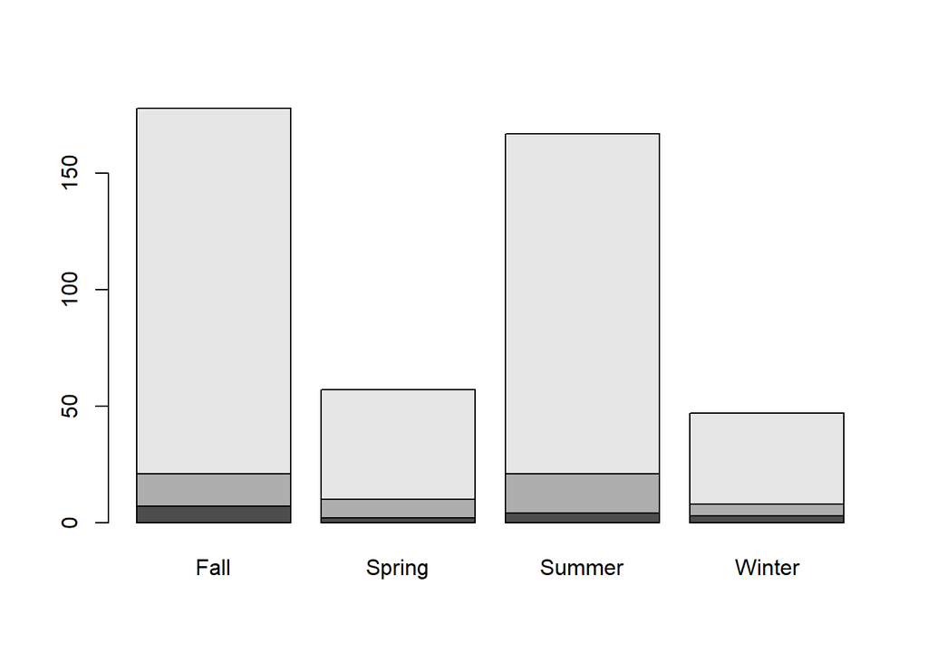

```r
# noMissing1
# noMissing2

barplot(withMissing)
```

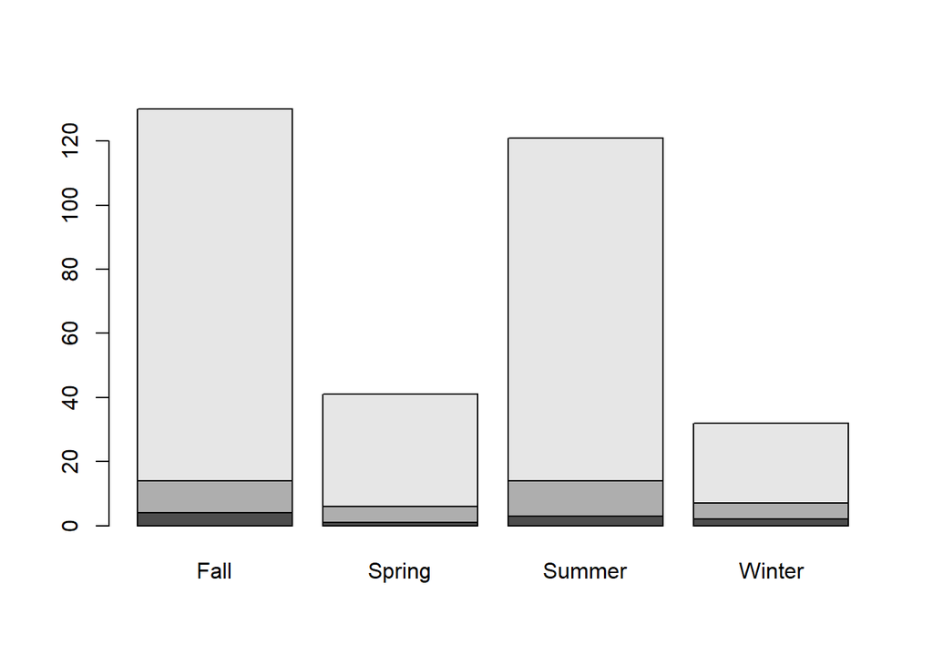

```r
barplot(noMissing1)
```

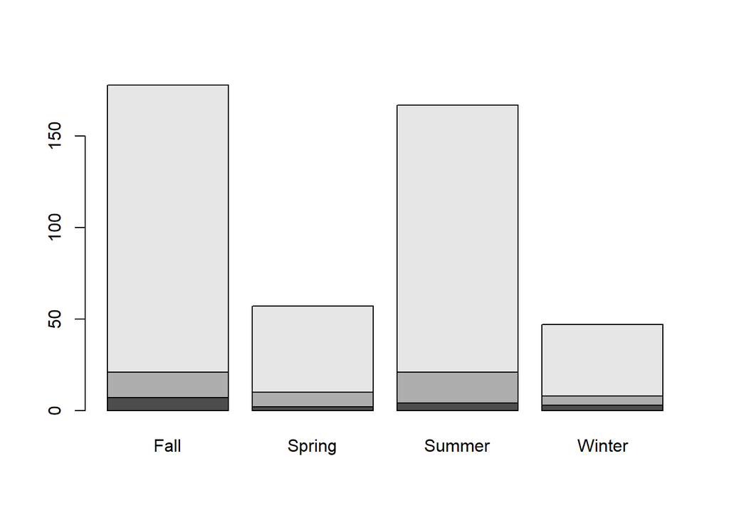

```r
barplot(noMissing2)
```

```r
sum(withMissing)
```

```
## [1] 449
```

```r
#Now lets do a permuted Chisq test

fisher.test(withMissing)
```

```
##
##  Fisher's Exact Test for Count Data
##
## data:  withMissing
## p-value = 0.6253
## alternative hypothesis: two.sided
```

```r
fisher.test(noMissing1)
```

```
##
##  Fisher's Exact Test for Count Data
##
## data:  noMissing1
## p-value = 0.6083
## alternative hypothesis: two.sided
```

```r
fisher.test(noMissing2)
```

```
##
##  Fisher's Exact Test for Count Data
##
## data:  noMissing2
## p-value = 0.6253
## alternative hypothesis: two.sided
```

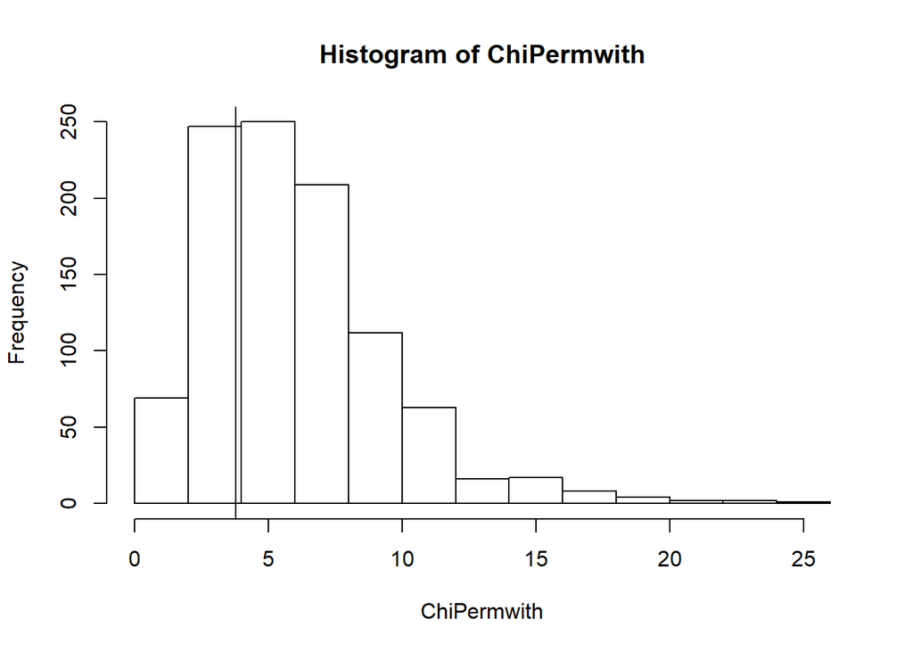

```r
XsqObs_with<-chisq.test(withMissing)$statistic
XsqObs_no1<-chisq.test(noMissing1)$statistic
XsqObs_no2<-chisq.test(noMissing2)$statistic

dat_with<-withMissing %>% melt() %>% expandRows("value")
dat_no1<-noMissing1 %>% melt() %>% expandRows("value")
dat_no2<-noMissing2 %>% melt() %>% expandRows("value") ## turns out this version is not actually different from the normal version

#permute the English scores to test independence with math
nperms<-1000
ChiPermwith<-rep(NA,nperms)
ChiPermno1<-rep(NA,nperms)
ChiPermno2<-rep(NA,nperms)

for ( i in 1:nperms){
  datPermutedwith<-dat_with
  datPermutedwith$Handed<-sample(datPermutedwith$Handed,length(datPermutedwith$Handed),replace=F)
  ChiPermwith[i]<-chisq.test(table(datPermutedwith))$statistic

  datPermutedno1<-dat_no1
  datPermutedno1$Handed<-sample(datPermutedno1$Handed,length(datPermutedno1$Handed),replace=F)
  ChiPermno1[i]<-chisq.test(table(datPermutedno1))$statistic

  datPermutedno2<-dat_no2
  datPermutedno2$Handed<-sample(datPermutedno2$Handed,length(datPermutedno2$Handed),replace=F)

  ChiPermno2[i]<-chisq.test(table(datPermutedno2))$statistic
}

hist(ChiPermwith)
abline(v=XsqObs_with)
```

```r
sum(ChiPermwith > XsqObs_with)/nperms
```

```
## [1] 0.722
```

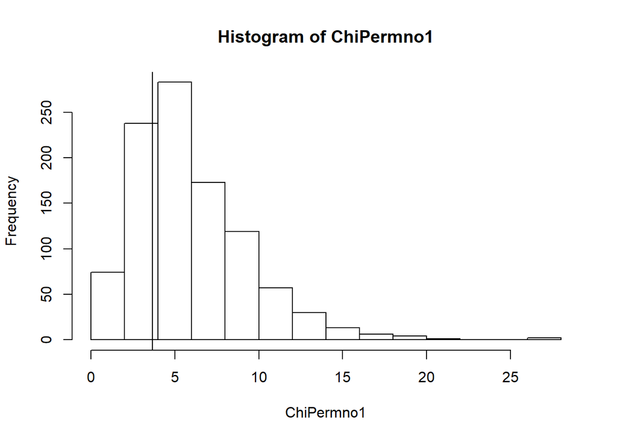

```r
hist(ChiPermno1)
abline(v=XsqObs_no1)
```

```r
sum(ChiPermno1 > XsqObs_no1)/nperms
```

```
## [1] 0.741
```

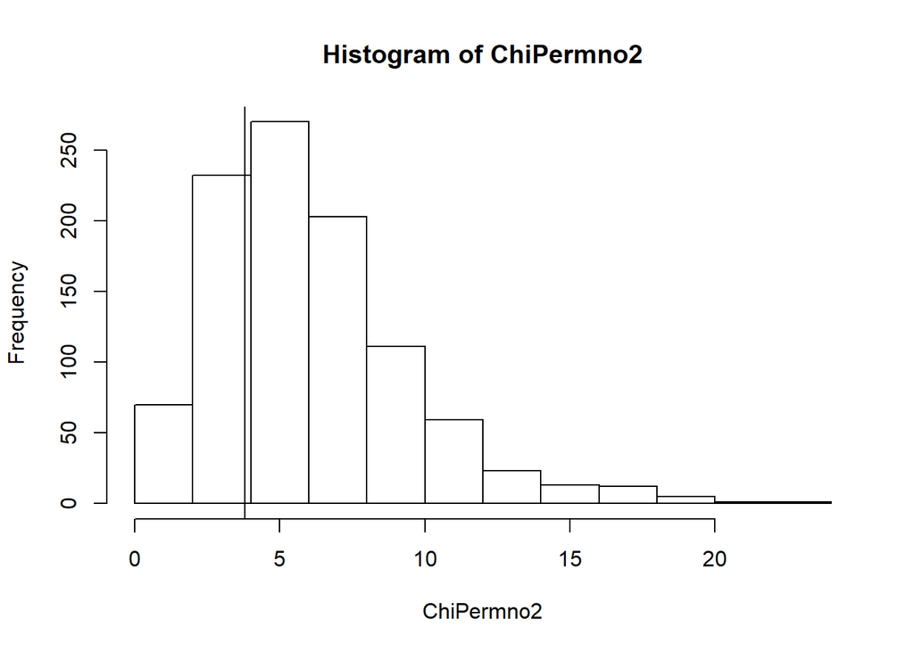

```r
hist(ChiPermno2)
abline(v=XsqObs_no2)
```

```r
sum(ChiPermno2 > XsqObs_no2)/nperms
```

```
## [1] 0.725
```

In general you should always hope to keep as much data as possible. Here you can argue that the decision is arbitrary because it can be assumed that there is no true association between the two data sets. However pvalues are sensitive to sample size especially in cases with small effect sizes. Removing observations arbitrarily reduces our power and opens up our analysis to more scrutiny.

Here we are dealing with two categorical variables with unbalanced groups, so I elected to use the permuted chisq test. Regardless of whether we use only complete data or not we do not find a significant relationship between the variables of handedness and favorite season. I also tested the data with a Fisher’s test and got the same result.

## Question 3

Build a simple linear regression model with height as your response and arm span as your predictor. First, you need to clean the data, then use MICE to impute missing values using a CART model. Estimate the simple linear regression model on each of the compeleted data sets and use Rubin’s combining rules to combined estiamtes across imputations. State your final estimates for each of the slope and intercept parameters as well as standard errors for each of these combined estimates.

```r
summary(school_data$Height_cm)
```

```
##    Length     Class      Mode
##       500 character character
```

```r
summary(school_data$Armspan_cm)
```

```
##    Length     Class      Mode
##       500 character character
```

```r
table(school_data$Height_cm)
```

```
##
##  1.80    10    12  12.7   120   122   130   140   143   144   147 147.3   149
##     1     1     1     1     1     1     1     1     1     1     2     1     1
##  149  149.8 149.9   150   151   152 152.4   153   154 154.9   155   156   157
##     1     1     1     3     2     2     7     3     1     2     9     4     7
## 157.3 157.4 157.5   158 158.4 158.5   159   160  160  160.2 160cm   161 161.3
##     1     4     3     7     1     1     1    24     1     1     1     3     1
##   162 162.5 162.6 162.7   163  163  163.5   164   165 165.1   166 166.2 166cm
##    14     7     1     1    18     1     1     6    30     6     5     1     1
##   167 167.6   168   169   170 170.1 170.2 170.6 170.7   171   172 172.5 172.7
##    12     4    11     5    29     1     3     1     1     8    12     1     4
##   173   174   175 175.3   176  176  176.5 176.7 176cm   177 177.8   178   179
##     9     4    10     3    10     1     1     1     1    10     2     9     7
##   180 180.3 180cm   181   182 182.5 182.8   183 183.8   184   185 185.4 185.6
##     8     2     1     4     7     1     3     9     1     2     6     1     1
##   186   187 187.5   188   190 190.5   192   193   196   197   200    26   330
##     4     5     1     2     1     4     1     2     2     1     1     1     1
##     5   5'2   5'3   5'5   5.2   5/2    54    57    58 59.25   6'0    60  61.5
##     3     1     1     1     1     1     1     1     1     1     1     2     1
##    63  63.5    64    68    69    70    71    72    73    75  75.6  78.4    80
##     3     1     5     2     1     2     1     1     1     1     1     1     2
##    98   999 99999
##     1     1     1
```

```r
table(school_data$Armspan_cm)
```

```
##
##   175  1.88   100   102    12   120   122   126   127   128   133   139   140
##     2     1     2     1     1     3     2     1     1     1     1     1     3
##   142 145.5   146   147   148   149 149.8   150 150.5   151 151.5   152 152cm
##     2     1     4     2     5     2     1     4     1     2     1     5     1
##   153   154 154.9   155 155cm   156 156.5   157 157.4   158   159 159.5   160
##     3     9     1    10     1     9     1    10     1     3     3     2    29
## 160.0   161   162 162.5   163   164 164.6   165 165.1 165.4   166 166.5   167
##     1     4    15     1    13    11     1    12     1     1     8     1     8
## 167.5   168   169   170 170.7   171   172 172.5   173 173.6   174 174.5   175
##     1     4     7    18     1     5     5     1     9     1     9     1    11
##   176 176cm   177 177.8   178   179   180 180cm   181 181.5 181.6   182   183
##    10     1     4     3    11     4    15     1     3     1     1     8     6
##   184   185 185.5   186   187   188   189   190 190.5   192   193   194   195
##     3     4     1     3     4     5     2     1     1     4     1     1     3
##   198   199    20   200   203    23   3'0    30    36  40.2 431.8    44    47
##     2     1     1     4     1     1     1     1     1     1     1     1     1
##    48     5    50    53    55    58  59.8    60    61    63    64    65   65
##     1     1     1     1     2     1     1     1     1     3     2     2     1
##    67    68    69    70    71    72    73    74    75    76    78    79    85
##     5     1     4     4     4     2     1     1     2     1     1     1     1
##   9.5    90    99   idk
##     1     1     1     1
```

```r
remove_characters<-function(string){
  string<-gsub("[^0-9.']","",string)
  string
}

feet_to_cm<-function(vector){ #there has to be a library that does exactly this
  # str(string)
  # str(vector)
  new_vec<-rep(0,length(vector))
  for (i in 1:length(vector)){
    if(grepl("'",vector[i],fixed=T)){
       foot<-as.numeric(as.character(unlist(strsplit(vector[i],"'",fixed=T))[1]))
       inch<-as.numeric(as.character(unlist(strsplit(vector[i],"'",fixed=T))[2]))
       # str(foot);str(inch)
       convert<-foot * 30.48 + inch * 2.54
       new_vec[i]<-convert
    } else {
      new_vec[i]<-as.numeric(vector[i])
    }
  }
  return(new_vec)
}

#also going to remove outliers, though some of the outliers are likely the result of a shifted decimal place this data is still suspect so I am cautiously going to remove it

slr_data<-school_data %>%
  mutate(Height_cm=remove_characters(Height_cm),Armspan_cm=remove_characters(Armspan_cm)) %>%
  mutate(Height_cm=feet_to_cm(Height_cm),Armspan_cm=feet_to_cm(Armspan_cm)) %>%
  mutate_if(is.character,as.factor) %>%
  mutate_if(is.factor,as.numeric)


summary(slr_data$Height_cm)
```

```
##    Min. 1st Qu.  Median    Mean 3rd Qu.    Max.    NA's
##     1.8   160.0   166.0   372.8   175.3 99999.0      29
```

```r
summary(slr_data$Armspan_cm)
```

```
##    Min. 1st Qu.  Median    Mean 3rd Qu.    Max.    NA's
##    1.88  154.00  164.00  153.36  175.00  431.80      50
```

```r
slr_data$Height_cm[slr_data$Height_cm > 300 | slr_data$Height_cm < 100]<-NA
slr_data$Armspan_cm[slr_data$Armspan_cm > 300 | slr_data$Armspan_cm < 100]<-NA

summary(slr_data$Height_cm)
```

```
##    Min. 1st Qu.  Median    Mean 3rd Qu.    Max.    NA's
##   120.0   162.0   168.0   168.4   176.0   200.0      72
```

```r
summary(slr_data$Armspan_cm)
```

```
##    Min. 1st Qu.  Median    Mean 3rd Qu.    Max.    NA's
##   100.0   159.1   166.0   166.7   176.8   203.0     110
```

The data has a number of issues, the basics of which includes clear outliers/errors, unwanted character strings, and incorrect units. I corrected basic unit conversions, removed escess strings and removed obviously problematic data. Additionally, I converted the data not used for regression into numeric sets for the mice function.

## Run the Cart imputation and compare

```r
predictors<-slr_data %>% select(-Height_cm,-Armspan_cm)


imputed_slr_data<-mice(data=slr_data,method = "cart")
dim(imputed_slr_data$imp$Height_cm)
```

```
## [1] 72  5
```

```r
dim(imputed_slr_data$imp$Armspan_cm)
```

```
## [1] 110   5
```

```r
Height_indexes<-as.numeric(rownames(imputed_slr_data$imp$Height_cm))
Armspan_indexes<-as.numeric(rownames(imputed_slr_data$imp$Armspan_cm))

regression_data<- slr_data %>% select(Height_cm,Armspan_cm )
regression_obj<-list()
for (i in 1:5){
  tmp<-regression_data
  tmp[Height_indexes,"Height_cm"]<-imputed_slr_data$imp$Height_cm[,i]
  tmp[Armspan_indexes,"Armspan_cm"]<-imputed_slr_data$imp$Armspan_cm[,i]
  regression_obj[[i]]<-lm(Height_cm ~ Armspan_cm,data=tmp)#$coefficient
}


cat("estmates of intercept and slope and their respective means:\n")
```

```
## estmates of intercept and slope and their respective means:
```

```r
model_estimates<-bind_rows(regression_obj[[1]]$coefficients,
                           regression_obj[[2]]$coefficients,
                           regression_obj[[3]]$coefficients,
                           regression_obj[[4]]$coefficients,
                           regression_obj[[5]]$coefficients)

mean_estimates<-colMeans(bind_rows(regression_obj[[1]]$coefficients,
                                   regression_obj[[2]]$coefficients,
                                   regression_obj[[3]]$coefficients,
                                   regression_obj[[4]]$coefficients,
                                   regression_obj[[5]]$coefficients))
(model_estimates - t(replicate(5,mean_estimates)))^2
```

```
##   (Intercept)   Armspan_cm
## 1  1.20918251 4.618843e-05
## 2  0.04428422 5.979301e-06
## 3 15.38715420 5.452361e-04
## 4  3.89960352 1.389522e-04
## 5  8.04910878 2.532375e-04
```

```r
cat("estmates of parameter variances:\n")
```

```
## estmates of parameter variances:
```

```r
model_variances<-bind_rows(
summary(regression_obj[[1]])$coefficients[,'Std. Error'],
summary(regression_obj[[2]])$coefficients[,'Std. Error'],
summary(regression_obj[[3]])$coefficients[,'Std. Error'],
summary(regression_obj[[4]])$coefficients[,'Std. Error'],
summary(regression_obj[[5]])$coefficients[,'Std. Error'])
model_variances
```

```
## # A tibble: 5 x 2
##   `(Intercept)` Armspan_cm
##           <dbl>      <dbl>
## 1          3.45     0.0206
## 2          3.65     0.0218
## 3          3.37     0.0201
## 4          3.41     0.0204
## 5          3.46     0.0207
```

```r
within<-colMeans(bind_rows(
summary(regression_obj[[1]])$coefficients[,'Std. Error'],
summary(regression_obj[[2]])$coefficients[,'Std. Error'],
summary(regression_obj[[3]])$coefficients[,'Std. Error'],
summary(regression_obj[[4]])$coefficients[,'Std. Error'],
summary(regression_obj[[5]])$coefficients[,'Std. Error']))
cat("within parameter variances :\n")
```

```
## within parameter variances :
```

```r
within
```

```
## (Intercept)  Armspan_cm
##  3.46474173  0.02072873
```

```r
between<- 5/4 * colMeans((model_estimates - t(replicate(5,mean_estimates)))^2)
cat("between parameter variances :\n")
```

```
## between parameter variances :
```

```r
between
```

```
##  (Intercept)   Armspan_cm
## 7.1473333086 0.0002473984
```

```r
within + (1 + 1/5) * between
```

```
## (Intercept)  Armspan_cm
## 12.04154170  0.02102561
```

## Question 4

Repeat the previous problem, but use a random forest for imputation in MICE instead of a cart model.

```r
imputed_slr_data<-mice(data=slr_data,method = "rf")
dim(imputed_slr_data$imp$Height_cm)
```

```
## [1] 72  5
```

```r
dim(imputed_slr_data$imp$Armspan_cm)
```

```
## [1] 110   5
```

```r
Height_indexes<-as.numeric(rownames(imputed_slr_data$imp$Height_cm))
Armspan_indexes<-as.numeric(rownames(imputed_slr_data$imp$Armspan_cm))

regression_data<- slr_data %>% select(Height_cm,Armspan_cm )
regression_obj<-list()
for (i in 1:5){
  tmp<-regression_data
  tmp[Height_indexes,"Height_cm"]<-imputed_slr_data$imp$Height_cm[,i]
  tmp[Armspan_indexes,"Armspan_cm"]<-imputed_slr_data$imp$Armspan_cm[,i]
  regression_obj[[i]]<-lm(Height_cm ~ Armspan_cm,data=tmp)#$coefficient
}


cat("estmates of intercept and slope and their respective means:\n")
```

[output not shown]

```r
model_estimates<-bind_rows(regression_obj[[1]]$coefficients,
                           regression_obj[[2]]$coefficients,
                           regression_obj[[3]]$coefficients,
                           regression_obj[[4]]$coefficients,
                           regression_obj[[5]]$coefficients)

mean_estimates<-colMeans(bind_rows(regression_obj[[1]]$coefficients,
                                   regression_obj[[2]]$coefficients,
                                   regression_obj[[3]]$coefficients,
                                   regression_obj[[4]]$coefficients,
                                   regression_obj[[5]]$coefficients))
# (model_estimates - t(replicate(5,mean_estimates)))^2


cat("estmates of parameter variances :\n")
```

```
## estmates of parameter variances :
```

```r
model_variances<-bind_rows(
summary(regression_obj[[1]])$coefficients[,'Std. Error'],
summary(regression_obj[[2]])$coefficients[,'Std. Error'],
summary(regression_obj[[3]])$coefficients[,'Std. Error'],
summary(regression_obj[[4]])$coefficients[,'Std. Error'],
summary(regression_obj[[5]])$coefficients[,'Std. Error'])
model_variances
```

```
## # A tibble: 5 x 2
##   `(Intercept)` Armspan_cm
##           <dbl>      <dbl>
## 1          4.25     0.0254
## 2          3.90     0.0233
## 3          4.06     0.0243
## 4          3.85     0.0229
## 5          3.88     0.0232
```

```r
within<-colMeans(bind_rows(
summary(regression_obj[[1]])$coefficients[,'Std. Error'],
summary(regression_obj[[2]])$coefficients[,'Std. Error'],
summary(regression_obj[[3]])$coefficients[,'Std. Error'],
summary(regression_obj[[4]])$coefficients[,'Std. Error'],
summary(regression_obj[[5]])$coefficients[,'Std. Error']))
cat("within parameter variances :\n")
```

```
## within parameter variances :
```

```r
within
```

```
## (Intercept)  Armspan_cm
##  3.98760898  0.02383066
```

```r
between<- 5/4 * colMeans((model_estimates - t(replicate(5,mean_estimates)))^2)
cat("between parameter variances :\n")
```

```
## between parameter variances :
```

```r
between
```

```
##  (Intercept)   Armspan_cm
## 2.386430e+01 8.261285e-04
```

```r
cat("combined parameter variances :\n")
```

```
## combined parameter variances :
```

```r
within + (1 + 1/5) * between
```

```
## (Intercept)  Armspan_cm
## 32.62477314  0.02482201
```

## Question 5

Finally, put your code and results in a github repository. In the final version of your homework that you submit to Sakai, the answer to this part will simply be a link to that github repository

https://github.com/RyanSchu/Nonparametric_HW6